# Лекция 2. Эксперимент как эталон

Блок 0. Данные и язык причинности

Карен Аванесян

Каузальный анализ в R на данных RLMS-HSE

# Зачем

## Зачем эксперименты в курсе про наблюдательные данные

- Рандомизированный эксперимент — **единственный** дизайн, где смещение отбора равно нулю по построению
- Все остальные методы курса — попытки **воспроизвести** эксперимент там, где его не было: мэтчинг имитирует рандомизацию по наблюдаемым, DiD — сравнение «до/после» с контрольной группой, IV — лотерею
- Чтобы понимать, чего мы пытаемся достичь, надо знать, как эталон устроен и как он ломается
- Практически: экспериментов в социальной политике становится больше, и анализировать их тоже надо уметь

## План занятия

1. Что даёт рандомизация и чего не даёт
2. Оценка эффекта и честные стандартные ошибки
3. Рандомизационный вывод: p-value без формул
4. Мощность: почему «незначимо» ≠ «эффекта нет»
5. Угрозы: некомплаенс, истощение, кластеры
6. Target trial: как думать об эксперименте, которого нет

# Идея

## Что делает рандомизация

Если $D$ назначен монетой, то $\{Y(0), Y(1)\} \perp D$, и

$$E[Y \mid D=1] - E[Y \mid D=0] = E[Y(1)] - E[Y(0)] = \text{ATE}$$

- Смещение отбора равно нулю **в среднем по рандомизациям**, а не в каждой конкретной
- Балансируются **все** характеристики — и измеренные, и нет. Таблица баланса проверяет только первые
- В конкретной выборке группы всё равно различаются случайно → стандартные ошибки измеряют именно это

Рандомизация решает проблему **идентификации** (что мы оцениваем), но не проблему **точности** (насколько хорошо).

## Как оценивать

| Подход | Что даёт | Когда |
| --- | --- | --- |
| Разница средних | ATE, без допущений о форме | всегда |
| Регрессия $Y \sim D$ | то же самое, плюс стандартная ошибка | всегда |
| Регрессия $Y \sim D + X$ | та же оценка, **точнее**, если $X$ объясняет $Y$ | ковариаты измерены **до** назначения |
| Регрессия с $D \times X$ | гетерогенность эффекта | заранее объявленные подгруппы |

- Стандартные ошибки — робастные к гетероскедастичности (HC2), `estimatr::lm_robust`
- Назначение на уровне групп (школ, регионов) → **кластерные** ошибки по группе
- Ковариаты не «исправляют» рандомизацию, они уменьшают шум

## Рандомизационный вывод (Fisher)

Вопрос: «насколько необычна наблюдаемая разница, если воздействие **ни на кого** не действует?»

**Точная нулевая** $Y_i(1) = Y_i(0)$ для всех — мы знаем **оба** потенциальных исхода каждого

**Переназначаем** $D$ случайно много раз, каждый раз считаем разницу средних

**p-value** = доля переназначений, где разница не меньше наблюдаемой

- Не нужны нормальность, большие выборки и формулы дисперсий; работает с любой статистикой
- Проверяет **точную** нулевую (эффект нулевой у всех), а не «средний эффект нулевой»

## Мощность

**Мощность** — вероятность обнаружить эффект, если он есть. Минимально обнаружимый эффект (MDE) при 80 % мощности и 5 % уровне:

$$\text{MDE} \approx 2.8 \cdot \sigma \sqrt{\frac{1}{n_1} + \frac{1}{n_0}}$$

≈ 12 % MDE зарплаты при 500 + 500 человек

0.7 $\sigma(\log w)$: зарплата очень дисперсна

5 % эффект программы — «незначим» почти всегда

- Лечится: больше $n$, ковариаты (снижают $\sigma$), исходы с меньшей дисперсией, стратификация
- **Незначимый результат при малой мощности — не доказательство отсутствия эффекта**

## Что ломает эксперимент

| Угроза | Что происходит | Что делать |
| --- | --- | --- |
| **Некомплаенс** | назначили, но не все прошли программу | оценивать ITT (эффект назначения) и LATE через IV (лекция 12) |
| **Истощение** | из групп выбывают по-разному | сравнить выбывших, границы (Lee bounds) |
| **Взаимовлияние** | контрольные учатся у обработанных | рандомизировать кластерами, измерять спилловеры |
| **Хоторн / ожидания** | люди меняют поведение, потому что за ними наблюдают | плацебо-группа, слепые дизайны |
| **Внешняя валидность** | эффект в выборке ≠ эффект в популяции | явно описывать, на кого обобщаем |

## Target trial: эксперимент, которого не было

Hernán & Robins: любой причинный анализ наблюдательных данных — **эмуляция** конкретного эксперимента. Сначала напишите его протокол:

| Компонент протокола | Для вопроса «диплом → зарплата» |
| --- | --- |
| Критерии включения | выпускники школ 17–18 лет, волна $t$ |
| Стратегии | поступить в вуз сразу / не поступать |
| Назначение | рандомизация (в эмуляции: условно на $X$ в $t$) |
| Начало отсчёта | год окончания школы |
| Исход | log зарплаты в $t + 12$ |
| Эстиманд | ITT-аналог: эффект стратегии, ATE |
| Анализ | сравнение групп с поправкой на $X$ в $t$ |

Половина ошибок в наблюдательных работах — это эксперименты, которые невозможно описать: «эффект образования» без времени начала и без стратегии.

# Код

## Плацебо-эксперимент внутри RLMS

Возьмём срез 2019 года и назначим «воздействие» монетой. Эффекта быть не может — проверим, что мы его и не находим:

```r
set.seed(19)
rct <- adults |>
  filter(year == 2019, employed == 1, !is.na(log_wage), !is.na(higher_ed)) |>
  mutate(d = rbinom(n(), 1, 0.5))

rct |> group_by(d) |>
  summarise(n = n(), log_wage = mean(log_wage), age = mean(age),
            female = mean(female), higher_ed = mean(higher_ed, na.rm = TRUE))
```

| d | n | log_wage | age | female | higher_ed |
| --- | --- | --- | --- | --- | --- |
| 0 | 3573 | 10.5 | 41.0 | 0.520 | 0.355 |
| 1 | 3573 | 10.5 | 40.8 | 0.528 | 0.356 |

## Таблица баланса

```r
bal <- rct |> select(d, age, female, higher_ed, log_wage, smokes, good_health)
datasummary_balance(~ d, data = bal, fmt = 2, dinm_statistic = "p.value")
```

|  | 0 Mean | 0 Std. Dev. | 1 Mean | 1 Std. Dev. | Diff. in Means | p |
| --- | --- | --- | --- | --- | --- | --- |
| age | 40.99 | 10.95 | 40.76 | 10.97 | −0.24 | 0.36 |
| female | 0.52 | 0.50 | 0.53 | 0.50 | 0.01 | 0.52 |
| higher_ed | 0.36 | 0.48 | 0.36 | 0.48 | 0.00 | 0.92 |
| log_wage | 10.53 | 0.67 | 10.52 | 0.68 | −0.01 | 0.41 |
| smokes | 0.33 | 0.47 | 0.34 | 0.47 | 0.01 | 0.43 |
| good_health | 0.48 | 0.50 | 0.48 | 0.50 | −0.01 | 0.62 |

В настоящем эксперименте таблицу баланса показывают, чтобы читатель увидел, что рандомизация **сработала**. Но «несбалансированную» переменную не выбрасывают: при 20 переменных одна «значимая» разница ожидаема.

## Оценка и честная стандартная ошибка

```r
fit_rct <- lm_robust(log_wage ~ d, data = rct)                       # HC2 по умолчанию
fit_rct
```

```
            Estimate Std. Error t value Pr(>|t|) CI Lower CI Upper   DF
(Intercept)  10.5318     0.0112 937.099    0.000  10.5098   10.554 7144
d            -0.0133     0.0160  -0.831    0.406  -0.0445    0.018 7144
```

```r
fit_cov <- lm_robust(log_wage ~ d + age + I(age^2) + female + higher_ed, data = rct)
tidy(fit_cov) |> filter(term == "d") |> select(term, estimate, std.error, p.value)
```

| term | estimate | std.error | p.value |
| --- | --- | --- | --- |
| d | -0.011 | 0.015 | 0.473 |

- Оценка не изменилась (ковариаты назначению не мешают), стандартная ошибка **уменьшилась**
- Это и есть законная роль контролей в эксперименте — точность, а не идентификация

## Как читать вывод `lm_robust()`

- Вывод R
- С пояснениями

```
Standard error type:  HC2
Coefficients:
            Estimate Std. Error t value Pr(>|t|) CI Lower CI Upper   DF
(Intercept)  10.5318     0.0112 937.099    0.000  10.5098   10.554 7144
d            -0.0133     0.0160  -0.831    0.406  -0.0445    0.018 7144
Multiple R-squared:  9.67e-05 , Adjusted R-squared:  -4.33e-05
F-statistic: 0.691 on 1 and 7144 DF,  p-value: 0.406
```

1 · тип ошибок

**HC2** — робастные к гетероскедастичности, умолчание `estimatr`. Для разницы средних в эксперименте они совпадают с консервативной дисперсией Неймана

2 · (Intercept)

Среднее лог зарплаты в **контрольной** группе ($d = 0$): 10.532

3 · d

Оценка ATE = разница средних: -0.013 лог-пункта, ≈ -1.3 %. Для плацебо так и должно быть: около нуля

4 · CI и DF

**CI Lower / CI Upper** — 95 %-й интервал, печатается сразу. **DF** = N − число коэффициентов = 7146 − 2. Интервал говорит, какие эффекты данные **исключают**

5 · R² и F

R² ≈ 0 — нормально: назначение монетой не объясняет зарплату. F-тест с одним регрессором — тот же t-тест ($F = t^2$)

6 · сигналы беды

Назначали по кластерам, а ошибки не кластерные (нужен `clusters =`); оценка сильно меняется от ковариат — проверьте рандомизацию; ДИ шире эффекта, который вас интересует

## Как писать результат

шаблон

«Воздействие назначено случайно половине из 7 146 работающих респондентов RLMS 2019 г. Разница средних логарифмов зарплаты между группами составила **-0.013** (робастная s.e. HC2 0.016; 95 % ДИ от -0.045 до 0.018). С поправкой на возраст, пол и высшее образование: -0.011 (s.e. 0.015). Данные исключают эффекты больше 4.5 % зарплаты по модулю.»

- Обязательно: единица и схема рандомизации, тип ошибок, заранее выбранные ковариаты, доля выбывших
- Не писать «эффекта нет» по $p > 0.05$: пишите, какие эффекты **исключает** доверительный интервал

## Плацебо с самоотбором: курение и рост

Теперь «воздействие» выбирают сами люди. Может ли курение изменить **рост**?

```r
ht <- adults |> filter(year %in% 2010:2012, !is.na(smokes), !is.na(height_cm))
etable(feols(height_cm ~ smokes, data = ht, cluster = ~psu),
       feols(height_cm ~ smokes + female + age, data = ht, cluster = ~psu),
       headers = c("наивная", "+ пол, возраст"), keep = "smokes", depvar = FALSE)
```

|  | feols(height_.. | feols(height.. |
| --- | --- | --- |
|  | наивная | + пол, возраст |
| smokes | 5.24*** (0.364) | -0.066 (0.229) |
| _______________ | _______________ | ______________ |
| S.E.: Clustered | by: psu | by: psu |
| Observations | 42,951 | 42,951 |
| R2 | 0.08 | 0.46 |

Курильщики «выше на 5 см» — пока не учтём пол: курят в основном мужчины, а мужчины выше. Наивная разница при самоотборе измеряет **кто выбрал**, а не **что сделало** воздействие.

## Рандомизационный вывод руками

- Результат
- Код

```
наблюдаемая     p_value
    -0.0133      0.3965
```

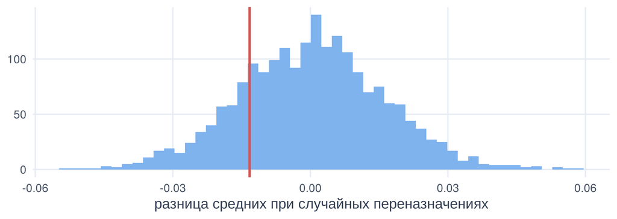

```r
diff_means <- function(y, d) mean(y[d == 1]) - mean(y[d == 0])
obs <- diff_means(rct$log_wage, rct$d)

set.seed(1)
perm <- replicate(2000, diff_means(rct$log_wage, sample(rct$d)))   # переназначаем D
c(наблюдаемая = obs, p_value = mean(abs(perm) >= abs(obs)))
```

## Тот же тест для реального «воздействия»

```r
obs_ed <- diff_means(rct$log_wage, rct$higher_ed)
perm_ed <- replicate(2000, diff_means(rct$log_wage, sample(rct$higher_ed)))
c(наблюдаемая = obs_ed, p_value = mean(abs(perm_ed) >= abs(obs_ed)),
  максимум_при_перестановках = max(abs(perm_ed)))
```

```
               наблюдаемая                    p_value максимум_при_перестановках
                    0.2579                     0.0000                     0.0566
```

p-value «меньше 1/2000». Это говорит лишь о том, что разница **не случайна**. Является ли она эффектом диплома — вопрос не к тесту, а к дизайну: диплом не назначался монетой.

## Мощность через симуляцию

Программа переобучения повышает зарплату на 5 %. Сколько людей нужно, чтобы это увидеть?

- Результат
- Код

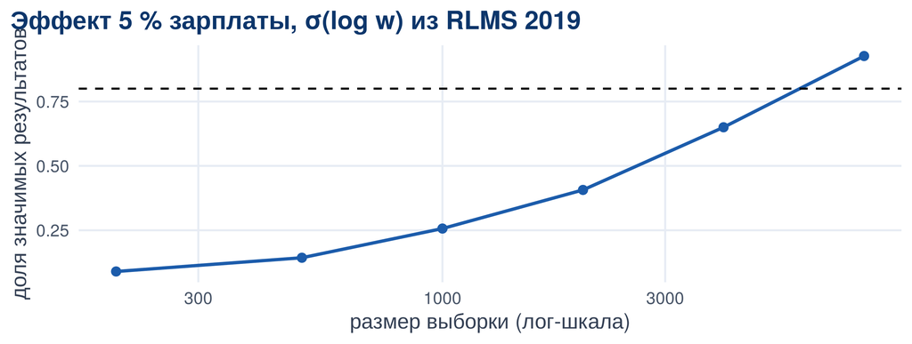

```r
sim_power <- function(n, effect = 0.05, reps = 300) {
  pool <- rct$log_wage
  mean(replicate(reps, {
    y <- sample(pool, n, replace = TRUE); d <- rbinom(n, 1, 0.5)
    y <- y + effect * d
    abs(obs <- diff_means(y, d)) / (sd(y) * sqrt(4 / n)) > 1.96
  }))
}
set.seed(7)
power <- tibble(n = c(200, 500, 1000, 2000, 4000, 8000)) |>
  mutate(мощность = map_dbl(n, sim_power))

ggplot(power, aes(n, мощность)) + geom_line(colour = pal["indigo"], linewidth = 1.1) +
  geom_point(size = 2.5, colour = pal["indigo"]) +
  geom_hline(yintercept = 0.8, linetype = 2) + scale_x_log10() +
  labs(x = "размер выборки (лог-шкала)", y = "доля значимых результатов",
       title = "Эффект 5 % зарплаты, σ(log w) из RLMS 2019")
```

## Кластерная рандомизация и ошибки

Программу вводят **по площадкам** (как делают регионы): случайно выбираем половину площадок. Эффекта снова нет:

```r
cluster_sim <- function() {
  treated_psu <- sample(unique(rct$psu), size = 19)
  d <- rct |> mutate(d = as.integer(psu %in% treated_psu))
  c(iid = pvalue(feols(log_wage ~ d, data = d))["d"],
    cl  = pvalue(feols(log_wage ~ d, data = d, cluster = ~psu))["d"])
}
set.seed(3)
pv <- replicate(300, cluster_sim())
c(`ложных открытий, iid SE` = mean(pv["iid.d", ] < 0.05),
  `ложных открытий, кластерные SE` = mean(pv["cl.d", ] < 0.05))
```

```
       ложных открытий, iid SE ложных открытий, кластерные SE
                        0.8367                         0.0633
```

Обычные ошибки «находят» эффект в разы чаще положенных 5 %. Единица рандомизации = единица кластеризации.

## Некомплаенс: ITT против эффекта участия

Назначили программу половине — но прошли её не все, а охотнее шли те, кто и так зарабатывает больше:

```r
sim_nc <- function() {
  nc <- rct |> mutate(
    z    = rbinom(n(), 1, 0.5),                                       # назначение
    took = rbinom(n(), 1, plogis(-2.2 + 2.5 * z + 1.2 * (log_wage - 10.5))),
    y    = log_wage + 0.10 * took)                                    # эффект участия = 0.10
  c(ITT = diff_means(nc$y, nc$z), `наивно по участию` = diff_means(nc$y, nc$took),
    `ITT / разница в участии` = diff_means(nc$y, nc$z) / diff_means(nc$took, nc$z))
}
set.seed(5); rowMeans(replicate(200, sim_nc()))                       # среднее по 200 повторам
```

```
                    ITT       наивно по участию ITT / разница в участии
                 0.0447                  0.4329                  0.0983
```

- **ITT** — честный эффект *назначения*; сравнение участников с неучастниками снова отравлено самоотбором
- ITT / разница в участии = эффект для **комплаеров** (LATE) — это уже IV, лекция 12

# Как ошибаются

## Семь ошибок в анализе экспериментов

1. Сравнивают участников с неучастниками вместо назначенных с неназначенными
2. Выбрасывают «несбалансированные» ковариаты или перезапускают рандомизацию
3. Назначили по школам, стандартные ошибки — по ученикам
4. Ищут эффект в 15 подгруппах и публикуют две «значимые»
5. «Эффекта нет» при мощности 20 %
6. Добавляют ковариаты, измеренные **после** назначения (они сами — исходы)
7. Забывают про выбывших: в контрольной группе анкеты вернули 90 %, в обработанной — 60 %

## Что обязательно должно быть в отчёте об эксперименте

- Единица рандомизации и способ (простая, стратифицированная, кластерная)
- Таблица баланса по **предварительно** объявленным ковариатам
- Доля комплаенса и истощения по группам
- ITT как основной результат; LATE — как дополнительный
- Пререгистрированные исходы и подгруппы; остальное — «поисковый анализ»
- Расчёт мощности **до** сбора данных

# Мини-задача

## Задание к следующему занятию

1. Напишите протокол target trial для вопроса «как курение влияет на зарплату»: критерии включения, стратегии, время начала, исход, эстиманд. Какой компонент труднее всего эмулировать на RLMS?
2. Повторите плацебо-эксперимент для другого исхода (здоровье, часы работы) и другого года. Сколько раз из 20 случайных назначений вы получите p < 0.05?
3. С помощью `sim_power()` найдите размер выборки, при котором эффект 5 % обнаруживается с мощностью 80 %, если исход — **занятость** (бинарная), а не зарплата
4. В симуляции с некомплаенсом измените долю участия в контрольной группе на 0.3. Что станет с ITT и с LATE?

# Литература

## Что прочитать

- Hernán M., Robins J. *What If*, гл. 2 «Randomized experiments» и гл. 22 «Target trial emulation»
- Athey S., Imbens G. (2017). The Econometrics of Randomized Experiments. *Handbook of Field Experiments* — рандомизационный вывод, ковариаты, кластеры
- Duflo E., Glennerster R., Kremer M. (2007). Using Randomization in Development Economics Research: A Toolkit — практика, мощность, угрозы
- Cunningham S. *The Mixtape*, раздел 4.1 — Fisher’s sharp null
- Пакеты: [`estimatr`](https://declaredesign.org/r/estimatr/), [`ri2`](https://github.com/acoppock/ri2), [`DeclareDesign`](https://declaredesign.org/) — симуляция дизайнов и мощности

Каузальный анализ в R · RLMS-HSE · К. Аванесян

← К программе курса